# Numpy basics, vectors, matrices

### Use of AI: can be used, but must be reported.

### AI shall not be used to complete the whole assignment.

## Execute every code cell and also take a look at the code and try to understand what is happening.

- Always wait until the cell is run. If you get errors, fix them before going any further.
- Example codes will help you in doing the tasks, understand the examples before going further.
- Do not alter the ready made code (unless otherwise instructed).

## Topics

- Python lists
- Numpy basics
- Vectors and vector operations
- Visualization
- Matrices and matrix operations

## Python List

Let's first recap some Python lists, later we'll learn how to convert these into NumPy arrays.

```python
# Create list with Python
list1 = [1,2,3,4,5,6,7]
print(list1)
```

```
[1, 2, 3, 4, 5, 6, 7]
```

```python
# print 1st item in the list
print(list1[0])
```

```
1
```

```python
# list could contain all kinds of data, that is not good for efficiency
list2 = [1,'car',3,True,list1,]
print(list2)
```

```
[1, 'car', 3, True, [1, 2, 3, 4, 5, 6, 7]]
```

## Numpy

- Numeric Python
- All items in the arrays must be same type (unlike in Pandas)

```python
import numpy as np
import matplotlib.pyplot as plt
from mpl_toolkits.mplot3d import Axes3D
```

### Numpy array

- ndarray = n-dimensional array
- dimension could be any: 1, 2, 3, 4, ..., n

### 1-dimensional array

```python
# Create 1-dimensional ndarray
np1d = np.array([1,2,3,4,5])
print(np1d)
```

```
[1 2 3 4 5]
```

```python
# check shape of the array
np1d.shape
```

```
(5,)
```

```python
# 'arange' can be used to create array
np1d = np.arange(10)
print(np1d)
```

```
[0 1 2 3 4 5 6 7 8 9]
```

```python
# 'arange' can contain 3 parameters: start value, end value, step)
np1d = np.arange(0, 20, 5)
print(np1d)
```

```
[ 0  5 10 15]
```

```python
# Create arrays with value 0
np1d = np.zeros(5)
print(np1d)
```

```
[0. 0. 0. 0. 0.]
```

### Multidimensional array

```python
# 2-dimensional array
np2d = np.array([[1,2,3],[4,5,6]])
print(np2d)
```

```
[[1 2 3]
 [4 5 6]]
```

```python
# 3-dimensional, all zeroes
np3d = np.zeros((3, 5))
print(np3d)
```

```
[[0. 0. 0. 0. 0.]
 [0. 0. 0. 0. 0.]
 [0. 0. 0. 0. 0.]]
```

### Convert Python list to Numpy array

```python
# covert previously created list1
print('Python list:', list1)
np1 = np.array(list1)
print('Numpy array:', np1)
```

```
Python list: [1, 2, 3, 4, 5, 6, 7]
Numpy array: [1 2 3 4 5 6 7]
```

### Good to know

```python
# type(arr): Returns the type of the Python object wrapper
type(list1)
```

```
list
```

```python
# Python's isinstance may also be handy.
print("This should be true:", isinstance(list1, list))
print("But this should be false:", isinstance(list1, int))
```

```
This should be true: True
But this should be false: False
```

```python
# arr.dtype is a NumPy array attribute that returns the data type of the elements stored inside a NumPy array
# (like int64, float32, bool)
np1.dtype

# But notice, you cannot use dtype for Python lists, you'll get an error if you were to use list1.dtype
```

```
dtype('int64')
```

```python
# print element in numpy array
print('Numpy array, first:', np1[0])

# Note the special case: index -1 points to last item
print('Numpy array, last:', np1[-1])
```

```
Numpy array, first: 1
Numpy array, last: 7
```

### Slicing arrays

#### 1D array

```python
# Create 1-dimensional ndarray
np1 = np.array([1,2,3,4,5,6,7,8,9,10])
# print slice
print(np1[1:6])
```

```
[2 3 4 5 6]
```

```python
# print all values starting from specific location
print(np1[5:])
```

```
[ 6  7  8  9 10]
```

```python
# print negative slices
# -5 (start) "Begin 5 elements before the end of the array."
# -1 (stop)	"Stop just before the last element."
print(np1[-5:-1])
```

```
[6 7 8 9]
```

```python
# slices in steps
print(np1[1:6])
# start 1 Begin at index 1 (the 2nd element, zero-based).
# stop 6 Stop before index 6 (exclusive).
# step 2 Advance by 2 positions each time — take every other element.
print(np1[1:6:2]) # some data in steps of 2
# start from 0, until end, step 2
print(np1[::2]) # all data in steps of 2
```

```
[2 3 4 5 6]
[2 4 6]
[1 3 5 7 9]
```

#### 2D array

```python
np2 = np.array([[1,2,3,4,5],[6,7,8,9,10]])
np2
```

```
array([[ 1,  2,  3,  4,  5],
       [ 6,  7,  8,  9, 10]])
```

```python
# print based on index in the array
print(np2[1,2])
```

```
8
```

```python
# slice 2D array
# show in first row values in columns with indexes 1 - 3
print(np2[0:1,1:4])
```

```
[[2 3 4]]
```

```python
# show data in row with index 1
# show the first row in the array
print(np2[0,:])
```

```
[1 2 3 4 5]
```

```python
# Note that it is also an option to print this way
print(np2[0,])
```

```
[1 2 3 4 5]
```

```python
# Show the last column in the array
print(np2[:,-1])
```

```
[ 5 10]
```

```python
# Show the previous result as array
a = np2[:, -1]
a
```

```
array([ 5, 10])
```

### Numpy functions

#### Statistical functions

https://numpy.org/doc/stable/reference/routines.statistics.html

```python
np1
```

```
array([ 1,  2,  3,  4,  5,  6,  7,  8,  9, 10])
```

```python
print(np.mean(np1))
```

```
5.5
```

```python
print(np.std(np1)) #standard deviation
```

```
2.8722813232690143
```

```python
print('Median of np1: ', np.median(np1))
```

```
Median of np1:  5.5
```

#### Transpose

```python
print('np2: ', np2)
```

```
np2:  [[ 1  2  3  4  5]
 [ 6  7  8  9 10]]
```

```python
np2t = np.transpose(np2)
print('Transposed np2: \n',  np2t)
```

```
Transposed np2:
 [[ 1  6]
 [ 2  7]
 [ 3  8]
 [ 4  9]
 [ 5 10]]
```

#### Indexes of numpy array

Find index of smallest and largest values

```python
# Create 1-dimensional Numpy arrays with random values.
np3 = np.random.rand(10)
print ('np3: \n', np3)
```

```
np3:
 [0.54765635 0.22316811 0.65068197 0.68830714 0.06213995 0.72879713
 0.56619319 0.10641853 0.94300719 0.93934113]
```

```python
# Find smallest and largest
np3min = np.argmin(np3)
np3max = np.argmax(np3)
print ('Index of smallest value is', np3min, 'with value:', np3[np3min])
print ('Index of largest value is', np3max, 'with value:', np3[np3max])
```

```
Index of smallest value is 4 with value: 0.06213995459518562
Index of largest value is 8 with value: 0.9430071949480959
```

#### Stacking arrays

```python
# Create 2-dimensional Numpy arrays
np4 = np.array([1,2,3,4])
np5 = np.array([5,6,7,8])
```

```python
# Stack the arrays
np4_5 = np.stack((np4, np5))
print ('np4 and np5 stacked: \n', np4_5)
```

```
np4 and np5 stacked:
 [[1 2 3 4]
 [5 6 7 8]]
```

```python
# Stack the arrays horizontally
np4_5h = np.hstack((np4, np5))
print ('np4 and np5 stacked horizontally: \n', np4_5h)
```

```
np4 and np5 stacked horizontally:
 [1 2 3 4 5 6 7 8]
```

```python
# Stack vertically (= same as stack)
np4_5v = np.vstack((np4, np5))
print ('np4 and np5 stacked vertically: \n', np4_5v)
```

```
np4 and np5 stacked vertically:
 [[1 2 3 4]
 [5 6 7 8]]
```

#### Concatenate arrays

```python
# Create 2-dimensional Numpy arrays with random values.
np6 = np.random.rand(2,5)
print ('np6: \n', np6)

# Create 2-dimensional Numpy arrays with random values.
np7 = np.random.rand(2,5)
print ('np7: \n', np7)
```

```
np6:
 [[0.81514357 0.91208031 0.96741395 0.21125353 0.77598319]
 [0.45858354 0.16277238 0.57756417 0.08450401 0.83142161]]
np7:
 [[0.86589858 0.248134   0.20966649 0.34218327 0.70621257]
 [0.01252797 0.25156281 0.16424054 0.54254952 0.8369615 ]]
```

```python
np.concatenate((np6, np7), axis=0)
```

```
array([[0.81514357, 0.91208031, 0.96741395, 0.21125353, 0.77598319],
       [0.45858354, 0.16277238, 0.57756417, 0.08450401, 0.83142161],
       [0.86589858, 0.248134  , 0.20966649, 0.34218327, 0.70621257],
       [0.01252797, 0.25156281, 0.16424054, 0.54254952, 0.8369615 ]])
```

```python
np.concatenate((np6, np7), axis=1)
```

```
array([[0.81514357, 0.91208031, 0.96741395, 0.21125353, 0.77598319,
        0.86589858, 0.248134  , 0.20966649, 0.34218327, 0.70621257],
       [0.45858354, 0.16277238, 0.57756417, 0.08450401, 0.83142161,
        0.01252797, 0.25156281, 0.16424054, 0.54254952, 0.8369615 ]])
```

#### Copy and view

```python
# Create array with 'arange'
np8 = np.arange(0, 100, 5)
np8
```

```
array([ 0,  5, 10, 15, 20, 25, 30, 35, 40, 45, 50, 55, 60, 65, 70, 75, 80,
       85, 90, 95])
```

```python
# Make a copy
np9 = np8.copy()
np9
```

```
array([ 0,  5, 10, 15, 20, 25, 30, 35, 40, 45, 50, 55, 60, 65, 70, 75, 80,
       85, 90, 95])
```

```python
# Use view instead
np10 = np8.view()
np10
```

```
array([ 0,  5, 10, 15, 20, 25, 30, 35, 40, 45, 50, 55, 60, 65, 70, 75, 80,
       85, 90, 95])
```

```python
# Change value in original array (np8)
np8[0] = 100
np8
```

```
array([100,   5,  10,  15,  20,  25,  30,  35,  40,  45,  50,  55,  60,
        65,  70,  75,  80,  85,  90,  95])
```

```python
# Check values in the copy and view
print ('copy of np8: ', np9)
print ('view of np8: ', np10)
```

```
copy of np8:  [ 0  5 10 15 20 25 30 35 40 45 50 55 60 65 70 75 80 85 90 95]
view of np8:  [100   5  10  15  20  25  30  35  40  45  50  55  60  65  70  75  80  85
  90  95]
```

### Universal functions

https://numpy.org/doc/stable/reference/ufuncs.html

```python
# Square root
print(np1)
print(np.sqrt(np1))
```

```
[ 1  2  3  4  5  6  7  8  9 10]
[1.         1.41421356 1.73205081 2.         2.23606798 2.44948974
 2.64575131 2.82842712 3.         3.16227766]
```

```python
# Absolute values
np3 = np.array([-5,-3, -2, 0, 2, 5,7,9])
print(np.absolute(np3))
```

```
[5 3 2 0 2 5 7 9]
```

```python
# Exponential (e^x)
print(np3)
# np.exp(x) computes the exponential function eˣ for each element x in the array, where e ≈ 2.718281828 (Euler's number).
print(np.exp(np3))
```

```
[-5 -3 -2  0  2  5  7  9]
[6.73794700e-03 4.97870684e-02 1.35335283e-01 1.00000000e+00
 7.38905610e+00 1.48413159e+02 1.09663316e+03 8.10308393e+03]
```

```python
# min & max
print('min:', np.min(np3))
print('max:', np.max(np3))
```

```
min: -5
max: 9
```

### Vectors and Matrices

```python
# Vector
v = np.array([4, 5])
v
```

```
array([4, 5])
```

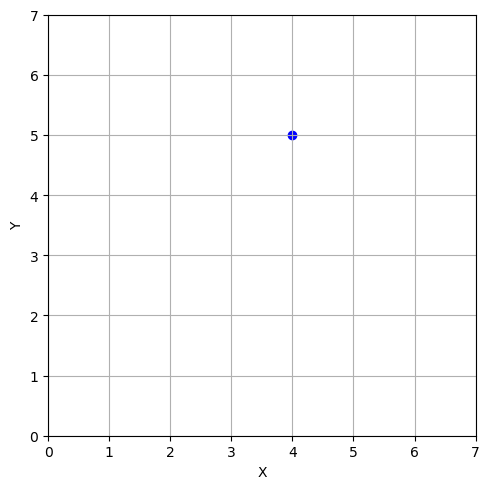

```python
#Plotting the vector as a data point
plt.scatter(v[0], v[1], color="blue")
plt.xlim([0, 7])
plt.ylim([0, 7])
plt.xlabel('X')
plt.ylabel('Y')
plt.grid()
plt.show()
```

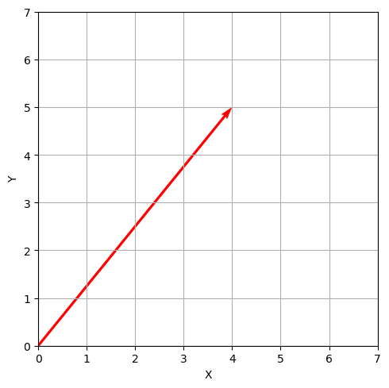

```python
# Plotting the vector as an array
origin = [0, 0]
plt.quiver(0, 0, v[0], v[1], angles="xy", scale_units="xy", scale = 1, color="red")
plt.xlim([0, 7])
plt.ylim([0, 7])
plt.xlabel('X')
plt.ylabel('Y')
plt.grid()
plt.show()
```

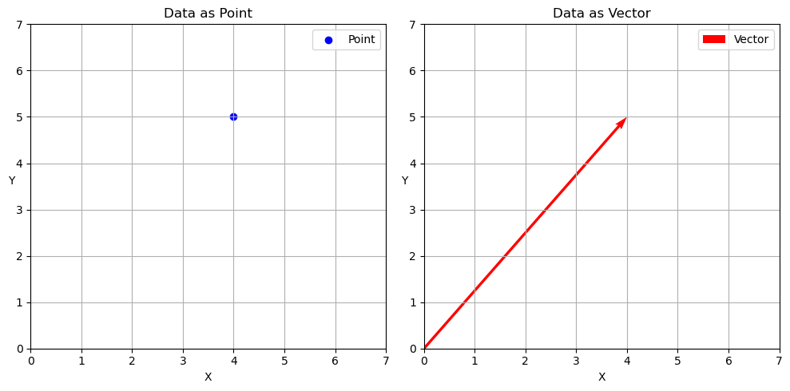

```python
# Print those as subplots in a single figure
fig, (ax1, ax2) = plt.subplots(1, 2, figsize=(10, 5))
# Subplot 1: Data as point
ax1.scatter(v[0], v[1], color='blue', label = 'Point')
ax1.set_title('Data as Point')
ax1.set_xlim(0, 7)
ax1.set_ylim(0, 7)
ax1.set_xlabel('X')
ax1.set_ylabel('Y', rotation = 0)
ax1.grid(True)
ax1.legend()
# Subplot 2: Vector
ax2.quiver(0, 0, v[0], v[1], angles='xy', scale_units='xy', scale=1, color='red', label ='Vector')
ax2.set_title('Data as Vector')
ax2.set_xlim(0, 7)
ax2.set_ylim(0, 7)
ax2.set_xlabel('X')
ax2.set_ylabel('Y', rotation = 0)
ax2.grid(True)
ax2.legend()
# Display the figure
plt.show()
```

#### 3D vector

```python
# Create 3D vector
a = np.array([2, 4, 5])
a
```

```
array([2, 4, 5])
```

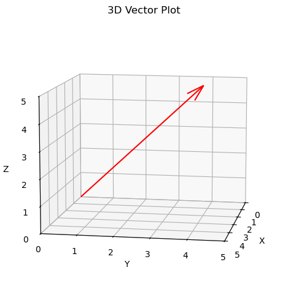

```python
# Plotting 3D vector as an array
fig = plt.figure()
ax = plt.axes(projection='3d')
ax.set_xlim([0, 5])
ax.set_ylim([0, 5])
ax.set_zlim([0, 5])
ax.set_xlabel('X')
ax.set_ylabel('Y')
ax.set_zlabel('Z')
ax.quiver(0, 0, 0, a[0], a[1], a[2], color='red', arrow_length_ratio=0.1)
ax.view_init(10,10)
plt.title('3D Vector Plot')
plt.show()
```

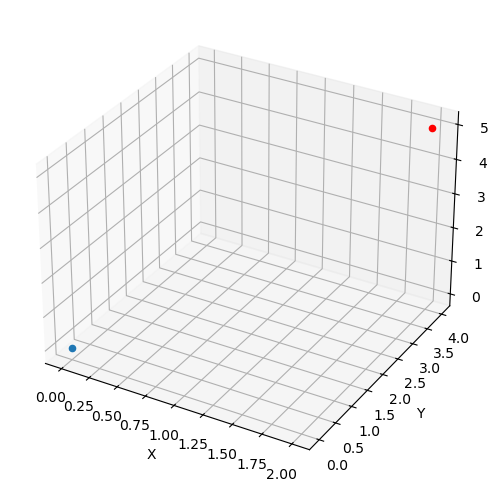

```python
# 3D vector as data point
plt.rcParams["figure.figsize"] = [5, 5]
plt.rcParams["figure.autolayout"] = True
fig = plt.figure()
ax = fig.add_subplot(111, projection='3d')
x = a[0]
y = a[1]
z = a[2]
ax.scatter(x, y, z, color ='red')
ax.scatter(0, 0, 0)
ax.set_xlabel('X')
ax.set_ylabel('Y')
ax.set_zlabel('Z')
plt.show()
```

#### Vector calculations

```python
# Vector a was created earlier
a
```

```
array([2, 4, 5])
```

```python
# Create another vector
b = np.array([5, 5, 5])
b
```

```
array([5, 5, 5])
```

```python
# Addition
a + b
```

```
array([ 7,  9, 10])
```

```python
# Subtraction
a - b
```

```
array([-3, -1,  0])
```

```python
# Multiplication
a * b
```

```
array([10, 20, 25])
```

```python
# Scalar multiplication
print(a)
print('5 x a =', 5*a)
```

```
[2 4 5]
5 x a = [10 20 25]
```

```python
# Dot product
print(a @ b)
```

```
55
```

#### Note: See more examples about vectors in:

https://github.com/ageron/handson-ml2/blob/master/math_linear_algebra.ipynb

## Matrices

Note: typically matrices and defined with big letters: e.g. X, A, M

```python
# Create a matrix with 3 rows and 4 columns
M = np.array([
    [1,2,3,4],
    [10,20,30,40],
    [100,200,300,400]])
M
```

```
array([[  1,   2,   3,   4],
       [ 10,  20,  30,  40],
       [100, 200, 300, 400]])
```

```python
# Show information about the matrix
print("Matrix shape:", M.shape)
print("Matrix size", M.size)
```

```
Matrix shape: (3, 4)
Matrix size 12
```

```python
# Create an identity matrix
I = np.eye(4)
print (I)
```

```
[[1. 0. 0. 0.]
 [0. 1. 0. 0.]
 [0. 0. 1. 0.]
 [0. 0. 0. 1.]]
```

```python
# Acess matrix and create vectors
# Use slicing methods similar with Pandas and Numpy
col_vector = M[:,2] # all rows from column in index 2
row_vector = M[1,:] # all columns from row in index 1
print('column vector in index 2:', col_vector)
print('row vector in index 1:', row_vector)
```

```
column vector in index 2: [  3  30 300]
row vector in index 1: [10 20 30 40]
```

### Matrix calculations

```python
# Addition
N = np.array([
    [0,0,0,0],
    [1,1,1,1],
    [2,2,2,2]])
print('M: \n', M)
print('N: \n', N)
print('N+M = \n', N+M)
```

```
M:
 [[  1   2   3   4]
 [ 10  20  30  40]
 [100 200 300 400]]
N:
 [[0 0 0 0]
 [1 1 1 1]
 [2 2 2 2]]
N+M =
 [[  1   2   3   4]
 [ 11  21  31  41]
 [102 202 302 402]]
```

### Multiplication using Dot product

Note: shapes of matrices needed for multiplication:

- If one has shape n x m, then another needs to have shape m x n

```python
# Impossible case as N and M have same shape, so this should cause an error (no need to fix it here)
# I comment out this code to prevent the runtime build error
# X = M.dot(N)
```

```python
L = np.array([
    [0,0,0],
    [1,1,1],
    [2,2,2],
    [3,3,3]])
L.shape
```

```
(4, 3)
```

```python
# Multiplicaton using Dot product
print('M:', M.shape,' \n', M)
print('L: , L.shape, \n', L)
X = M.dot(L)
print('M*L:',X.shape, '\n', X)
```

```
M: (3, 4)
 [[  1   2   3   4]
 [ 10  20  30  40]
 [100 200 300 400]]
L: , L.shape,
 [[0 0 0]
 [1 1 1]
 [2 2 2]
 [3 3 3]]
M*L: (3, 3)
 [[  20   20   20]
 [ 200  200  200]
 [2000 2000 2000]]
```

### More examples

#### Math - Linear Algebra

Read: https://github.com/ageron/handson-ml/blob/master/math_linear_algebra.ipynb

### Tasks (Numpy)

Complete following tasks with Numpy

```python
# Create a 1-dimensional array using np.array() containing 6 values
# Your code here
arr = np.array([10, 20, 30, 40, 50, 60])
print(arr)
```

```
[10 20 30 40 50 60]
```

```python
# Use slicing and show first 3 values in the array

# Slice the first 3 values
# Your code here

arr1 = arr[0:3]
# Alternative ways: arr1 = arr[:3]

# Print the result
# Your code here
print(f"First 3 elements of the array is {arr1}")
```

```
First 3 elements of the array is [10 20 30]
```

```python
# Use slicing and show the last value in the array

# Slice the last value
# Your code here

last_elem = arr[-1]

# Print the result
# Your code here
print(f"Last element of the array is {last_elem}")
```

```
Last element of the array is 60
```

```python
# Create a 2-dimensional array using np.array()
# Your code here
two_dimentional_arr = np.array([[1,2,3], [4,5,6]])

# Print the array
# Your code here
print(f"2-dimensional array using np.array(): \r\n{two_dimentional_arr}")
```

```
2-dimensional array using np.array():
[[1 2 3]
 [4 5 6]]
```

```python
# Use slicing and show the first row in the array

# Slice the first row
# Your code here

first_row = two_dimentional_arr[0,:]

# Print the result
# Your code here

print(f"Show first row: {first_row}")
```

```
Show first row: [1 2 3]
```

```python
# Use slicing and show the last column in the array

# Slice the last column row
# Your code here

last_column_row = two_dimentional_arr[:,-1]

# Print the result
# Your code here

print(f"Show last row: {last_column_row}")
```

```
Show last row: [3 6]
```

```python
# Create an array of shape (6, 2, 3) containing zeros

# Create the array of zeros with shape (6, 2, 3)
# Your code here

zero_array = np.zeros((6, 2, 3))

# Print the array and its shape
# Your code here

print(f"The zero array of the shape shape (6, 2, 3) is: {zero_array}")
print("Shape:", zero_array.shape)
```

```
The zero array of the shape shape (6, 2, 3) is: [[[0. 0. 0.]
  [0. 0. 0.]]

 [[0. 0. 0.]
  [0. 0. 0.]]

 [[0. 0. 0.]
  [0. 0. 0.]]

 [[0. 0. 0.]
  [0. 0. 0.]]

 [[0. 0. 0.]
  [0. 0. 0.]]

 [[0. 0. 0.]
  [0. 0. 0.]]]
Shape: (6, 2, 3)
```

```python
# Create an array within a range from 0 to 60 with step 3
# Your code here

arr = np.arange(0, 61, 3)

# Print the results
# print(arr)

print(f"an array within a range from 0 to 60 with step 3: {arr}")
```

```
an array within a range from 0 to 60 with step 3: [ 0  3  6  9 12 15 18 21 24 27 30 33 36 39 42 45 48 51 54 57 60]
```

```python
# Find mean for previous array  (array with range from 0 to 60 with step 3)
# Your code here
mean = arr.mean()
# Print the result
# Your code here
print(f"Mean value is {mean}")
```

```
Mean value is 30.0
```

```python
# Find standard deviation for previous array
# Your code here

st = arr.std()

# Print the result
# Your code here
print(f"Standard deviation value is {st}")
```

```
Standard deviation value is 18.16590212458495
```

```python
# Create a 2-dimensional array with dimension (3,4) i.e. 3 rows and 4 columns
# Then create transposed array with it
# Print both arrays
# Your code here
arr = np.array([[1,2,3,4],[5,6,7,8],[9,10,11,12]])
print(f"Original array: {arr}")

# Create a transposed array
transposed_array = arr.transpose()
print(f"Transposed array: {transposed_array}")
```

```
Original array: [[ 1  2  3  4]
 [ 5  6  7  8]
 [ 9 10 11 12]]
Transposed array: [[ 1  5  9]
 [ 2  6 10]
 [ 3  7 11]
 [ 4  8 12]]
```

```python
# Create another 2-dimensional array with dimension (3,4) containing ones
# Stack the 2-dimensional arrays vertically with array you created in previous task
# Your code here
another_arr = np.ones((3,4))
# Print the result
# Your code here
print(f"The array is {another_arr}")

# Stack the new array with the previous one
new_array = np.vstack((arr, another_arr))

print(f"The new (vertically) array is: {new_array}")
```

```
The array is [[1. 1. 1. 1.]
 [1. 1. 1. 1.]
 [1. 1. 1. 1.]]
The new (vertically) array is: [[ 1.  2.  3.  4.]
 [ 5.  6.  7.  8.]
 [ 9. 10. 11. 12.]
 [ 1.  1.  1.  1.]
 [ 1.  1.  1.  1.]
 [ 1.  1.  1.  1.]]
```

```python
# Stack the 2-dimensional arrays horizontally
# Your code here

new_horizontally_array = np.hstack((arr, another_arr))

# Print the result
# Your code here
print(f"The new (horizontally) array is: {new_horizontally_array}")
```

```
The new (horizontally) array is: [[ 1.  2.  3.  4.  1.  1.  1.  1.]
 [ 5.  6.  7.  8.  1.  1.  1.  1.]
 [ 9. 10. 11. 12.  1.  1.  1.  1.]]
```

```python
# Create a array containing 20 values
# Make a copy of it
# View it
# Change some values in the original array and verify how the copy and view are working
# Your code here

array20 = np.arange(0, 20, 1)
av = array20.view()

print(f"Array of 20 elements is {array20}")
print(f"View of it is {av}")

# Now change some values
array20[np.random.randint(0, 20)] = np.random.randint(0, 20)

# Print the result
# Your code here
print(f"After modifying, the array of 20 elements is {array20}")
print(f"After modifying, the view of it is {av}")

# Reflection: The view of an array works silimar to a pointer in C++, no actual new array created at all.
```

```
Array of 20 elements is [ 0  1  2  3  4  5  6  7  8  9 10 11 12 13 14 15 16 17 18 19]
View of it is [ 0  1  2  3  4  5  6  7  8  9 10 11 12 13 14 15 16 17 18 19]
After modifying, the array of 20 elements is [ 0  1  2  3  4  5  6 13  8  9 10 11 12 13 14 15 16 17 18 19]
After modifying, the view of it is [ 0  1  2  3  4  5  6 13  8  9 10 11 12 13 14 15 16 17 18 19]
```

### Tasks (vectors and matrices)

```python
# Create vectors 'v' and 'w' containing 2 values e.g [5, 6] and [7, 8]
# Your code here

v = np.array([5, 6])
w = np.array([7, 8])

# Print the result
# Your code here

print(f"Vector v = {v}, vector w = {w}")
```

```
Vector v = [5 6], vector w = [7 8]
```

```python
# Calculate sum v + w
# Your code here

sum = v + w

# Print the result
# Your code here
print(f"Sum of v + w = {v + w}")
```

```
Sum of v + w = [12 14]
```

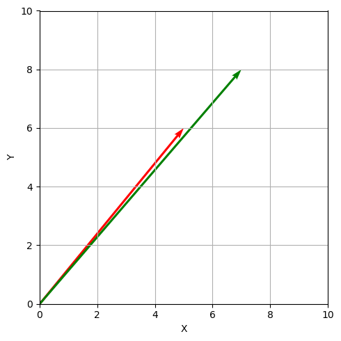

```python
# Plot the vectors v, w and v in one / same figure (no subplots here)
# Your code here
plt.quiver(0, 0, v[0], v[1], angles="xy", scale_units="xy", scale = 1, color="red")
plt.quiver(0, 0, w[0], w[1], angles="xy", scale_units="xy", scale = 1, color="green")
plt.xlim([0, 10])
plt.ylim([0, 10])
plt.xlabel('X')
plt.ylabel('Y')
plt.grid()
plt.show()
```

```python
# Create matrices A with shape (2,3), B with shape (2, 3) and C with shape (3, 2)
# Your code here
A = np.array([
    [1,2,3],
    [4,5,6]])
B = np.array([
    [10,20,30],
    [40,50,60]])
C = np.array([
    [100,200],
    [300,400],
    [500,600]])
# Print the result
# Your code here
print(f"Matrix A = {A}, shape: {A.shape}\r\n")
print(f"Matrix B = {B}, shape: {B.shape}\r\n")
print(f"Matrix C = {C}, shape: {C.shape}")
```

```
Matrix A = [[1 2 3]
 [4 5 6]], shape: (2, 3)

Matrix B = [[10 20 30]
 [40 50 60]], shape: (2, 3)

Matrix C = [[100 200]
 [300 400]
 [500 600]], shape: (3, 2)
```

```python
# Calculate addition of matrices A + B
# Your code here

A_ADD_B = A + B

# Print the result
# Your code here
print(f"A + B = {A_ADD_B}, shape: {A_ADD_B.shape}\r\n")
```

```
A + B = [[11 22 33]
 [44 55 66]], shape: (2, 3)
```

```python
# Calculate multiplication A * C
# Your code here

A_MUL_C = A @ C

# Print the result
# Your code here
print(f"A * C = {A_MUL_C}, shape: {A_MUL_C.shape}\r\n")
```

```
A * C = [[2200 2800]
 [4900 6400]], shape: (2, 2)
```

### Task, AI statement

- I used AI to correct programming syntax errors.

### Task return

- File > Save and Export Notebook As > HTML
- Then take a look the produced HTML that it looks ok and readable
- Return to Itslearning, only the html document is returned, *not the .ipynb